# 基本繪圖 (ggplot2)

朱志泓

2017年2月21日

本章節將使用套件`ggplot2`，同[前一節](https://hank830214.github.io/r_prg_web/based_plotting)，繪出散佈圖、線圖、直方圖、盒鬚圖和長條圖。

# **0. 安裝及載入套件`ggplot2`**

# 安裝套件

```
install.packages("ggplot2")
```

# 載入套件

```r
library(ggplot2)
```

載入套件後，將發現將新增更多玩具資料，可於`data()`查詢。

接下來將一致使用`ggplot`函數繪圖。

# **1. 散佈圖(Scatter)**

玩具資料採用`cars`，觀察車速(speed)與煞車距離(dist)之關係。

## **1.1. 畫散佈圖**

# aes：輸入x軸與y軸資料

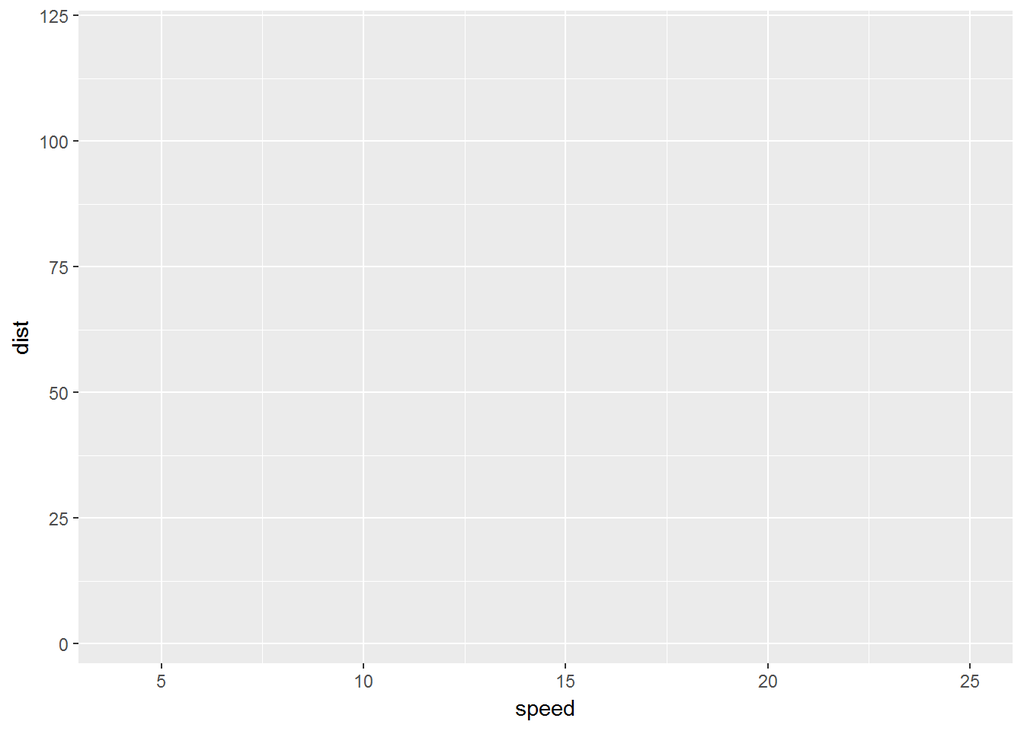

```r
ggplot(cars, aes(x = speed, y = dist))
```

發現點不會自動顯示出來，使用“+”來進行函數疊加。

# geom_point()：畫點

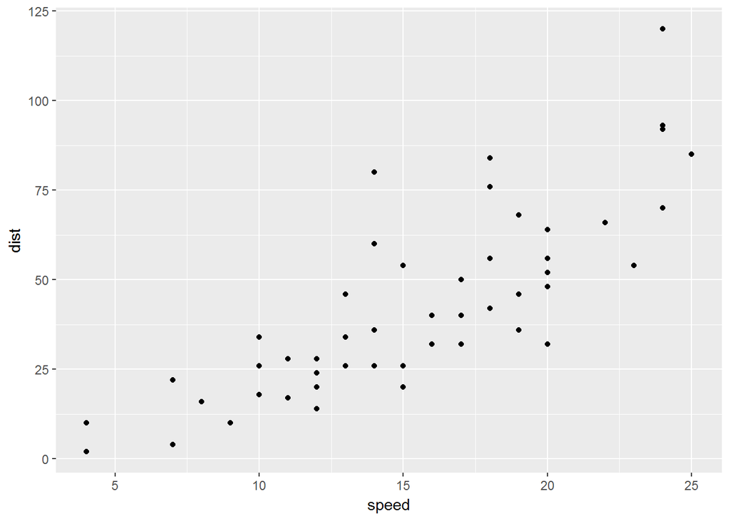

```r
ggplot(cars, aes(x = speed, y = dist)) +
  geom_point()
```

亦可以先將畫布指派到變數

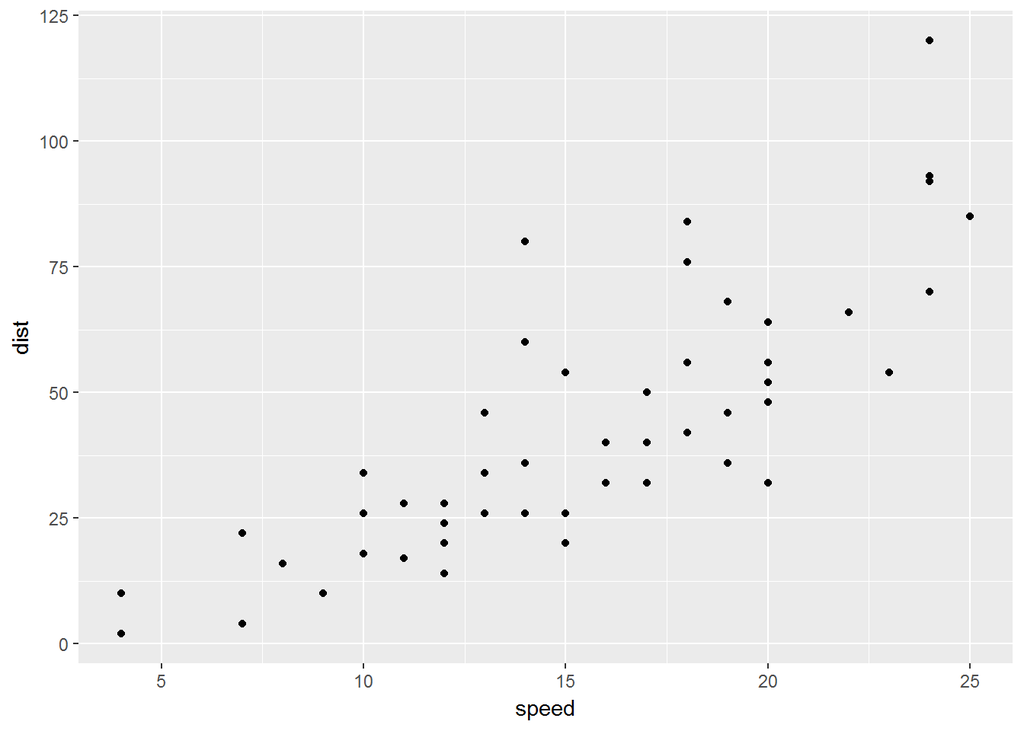

```r
ggplot_without_points <- ggplot(cars, aes(x = speed, y = dist))
ggplot_without_points +
　geom_point()
```

加入圖片標題(類似`main`)與座標名稱

# ggtitle：圖片標題

# xlab()：給x座標名稱

# ylab()：給y座標名稱

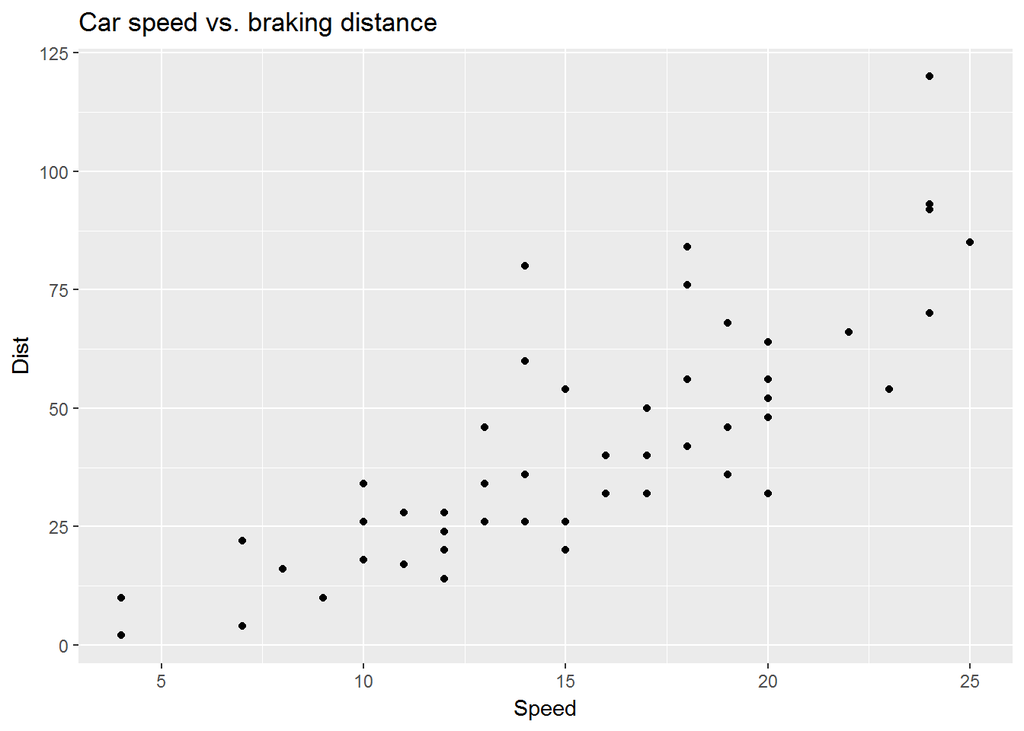

```r
ggplot(cars, aes(x = speed, y = dist)) +
  geom_point() +
  ggtitle("Car speed vs. braking distance") +
  xlab("Speed") +
  ylab("Dist")
```

## **1.2. 其他功能**

### **1.2.1 加入回歸線**

# geom_smooth(method = …)：加入最適線，“lm”代表回歸方法用linear modol

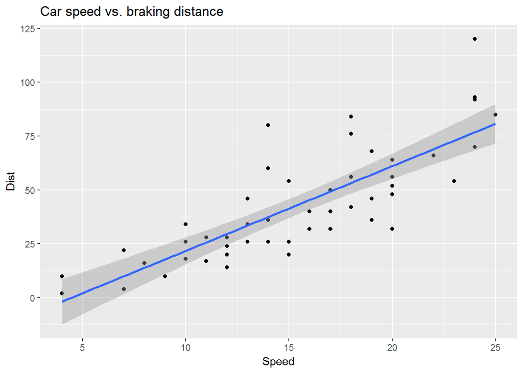

```r
ggplot(cars, aes(x = speed, y = dist)) +
  geom_point() +
  ggtitle("Car speed vs. braking distance") +
  xlab("Speed") +
  ylab("Dist") +
  geom_smooth(method = "lm")
```

可至`?geom_smooth`查詢其他回歸方法

# se：是否顯示confidence interval，預設為TRUE

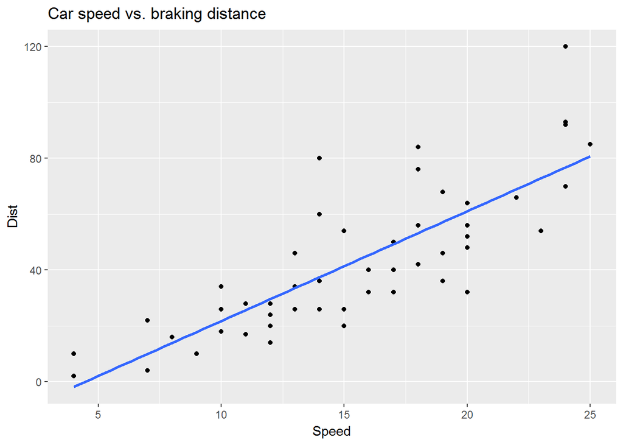

```r
ggplot(cars, aes(x = speed, y = dist)) +
  geom_point() +
  ggtitle("Car speed vs. braking distance") +
  xlab("Speed") +
  ylab("Dist") +
  geom_smooth(method = "lm", se = FALSE)
```

### **1.2.2 顏色調整**

玩具資料採用`iris`，依照不同品種(Species)來觀察萼片(Sepal)之長度(Length)與寬度(Width)之分布。

`aes()`中加入引數`color`

尚未依照品種區分之散佈圖

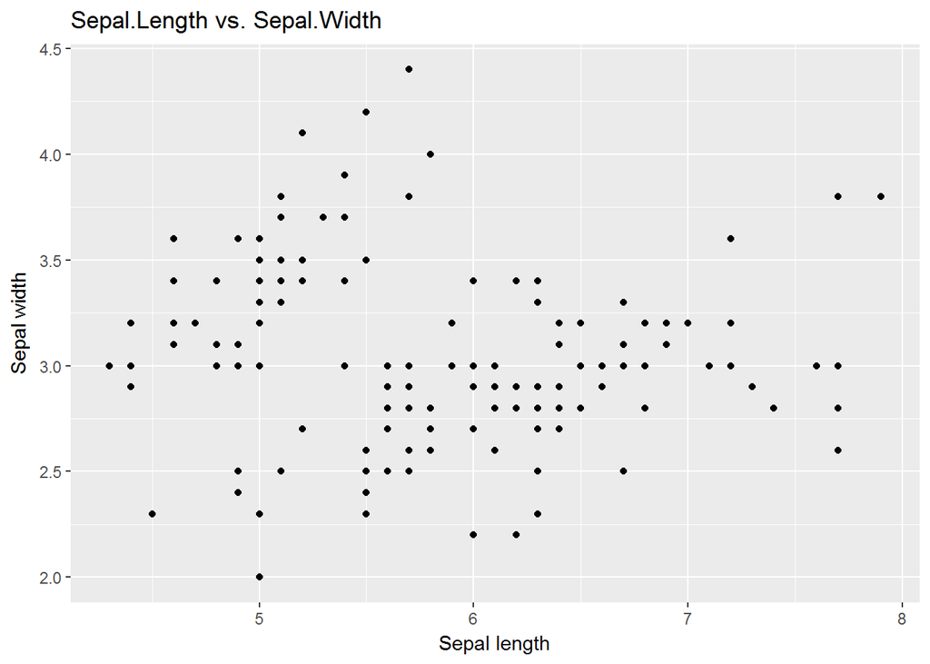

```r
ggplot(iris, aes(x = Sepal.Length, y = Sepal.Width)) +
  geom_point() +
  ggtitle("Sepal.Length vs. Sepal.Width") +
  xlab("Sepal length") +
  ylab("Sepal width")
```

依品種(Species)按顏色區分

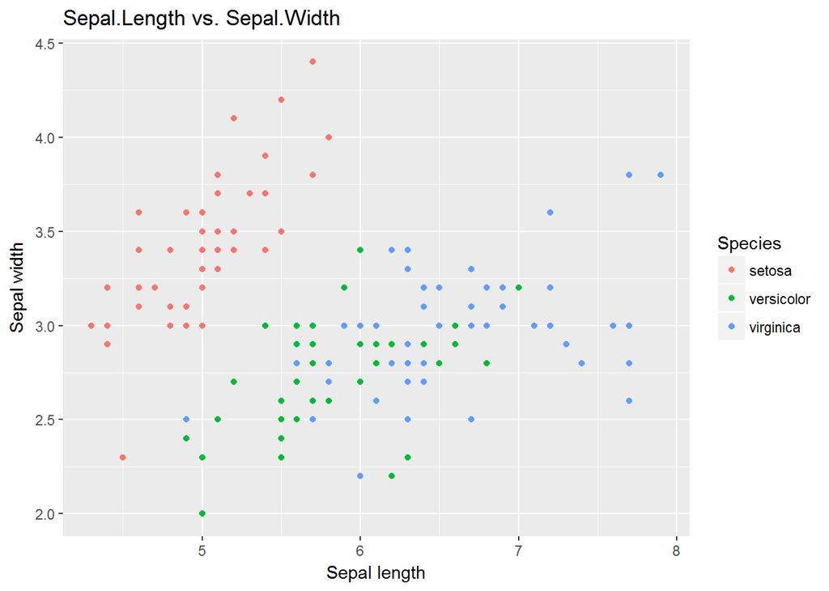

```r
ggplot(iris, aes(x = Sepal.Length, y = Sepal.Width, color = Species)) +
  geom_point() +
  ggtitle("Sepal.Length vs. Sepal.Width") +
  xlab("Sepal length") +
  ylab("Sepal width")
```

# **2. 線圖(Line Graph)**

玩具資料採用`diamonds`，觀察鑽石長度(x)與闊度(y)之關係。

```r
my_diamonds <- head(diamonds, n = 15L)
```

## **2.1. 畫線圖**

# geom_line()：畫線

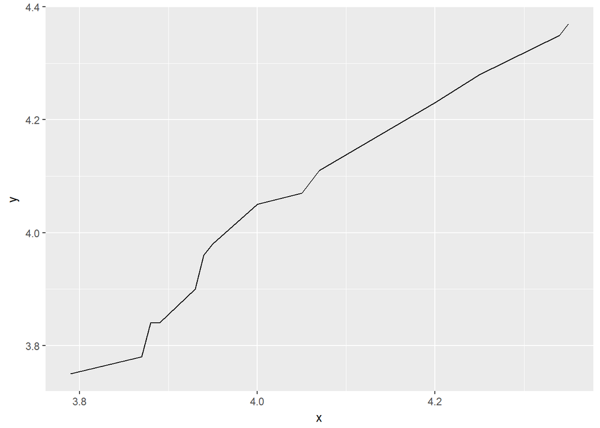

```r
ggplot(my_diamonds, aes(x = x, y = y)) +
  geom_line()
```

發現geom_line的畫線順序自動會以x軸資料之大小排序

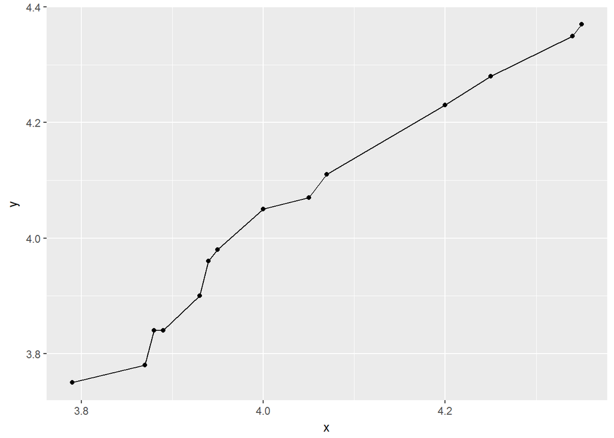

```r
ggplot(my_diamonds, aes(x = x, y = y)) +
　geom_point() +
  geom_line()
```

## **2.2. 其他功能**

### **2.2.1 上色**

# colour：調整顏色

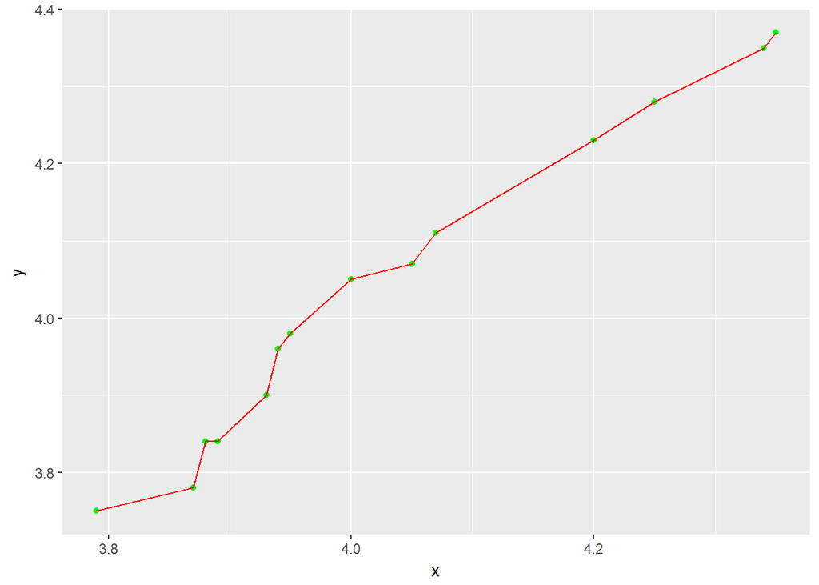

```r
ggplot(my_diamonds, aes(x = x, y = y)) +
  geom_point(colour = "green") +
  geom_line(colour = "red")
```

線圖常用來視覺化時間序列

```r
head(economics)
```

```
## # A tibble: 6 × 6
##         date   pce    pop psavert uempmed unemploy
##       <date> <dbl>  <int>   <dbl>   <dbl>    <int>
## 1 1967-07-01 507.4 198712    12.5     4.5     2944
## 2 1967-08-01 510.5 198911    12.5     4.7     2945
## 3 1967-09-01 516.3 199113    11.7     4.6     2958
## 4 1967-10-01 512.9 199311    12.5     4.9     3143
## 5 1967-11-01 518.1 199498    12.5     4.7     3066
## 6 1967-12-01 525.8 199657    12.1     4.8     3018
```

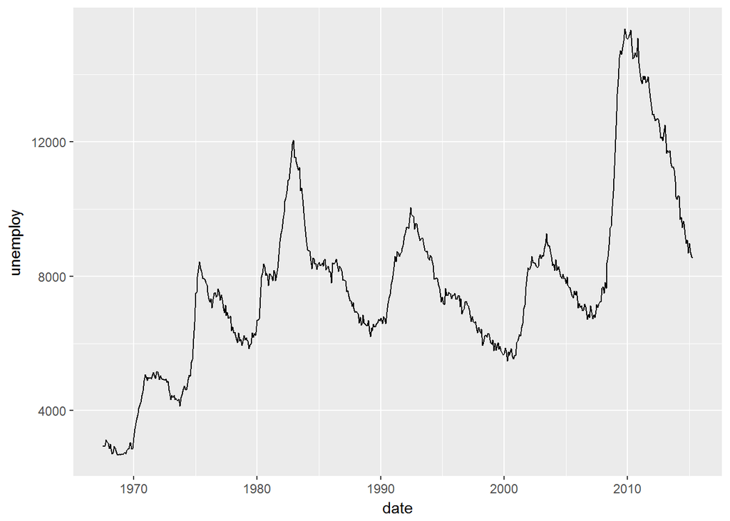

```r
ggplot(economics, aes(x = date, y = unemploy)) +
  geom_line()
```

# **3. 直方圖(Histogram)**

## **3.1. 畫直方圖**

玩具資料採用`iris`，觀察萼片(Sepal)之長度(Length)之分布。

使用`ggplot() + geom_histogram()`繪製直方圖

# binwidth：調整分箱寬度

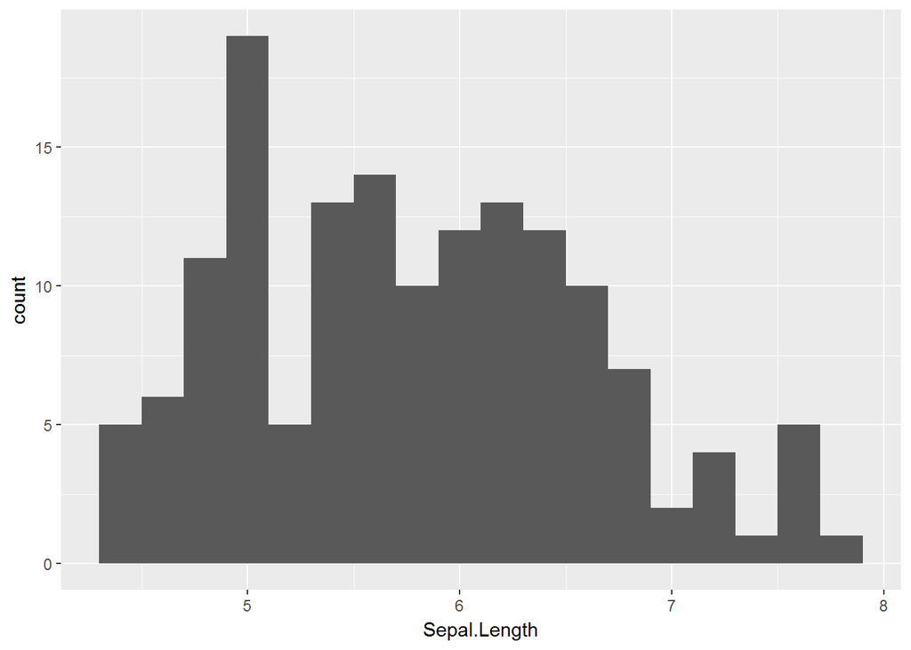

```r
ggplot(iris, aes(x = Sepal.Length)) +
  geom_histogram(binwidth = 0.2)
```

## **3.2. 其他功能**

### **3.2.1. 分類畫圖**

# facet_wrap()：納入類別變數分別畫圖

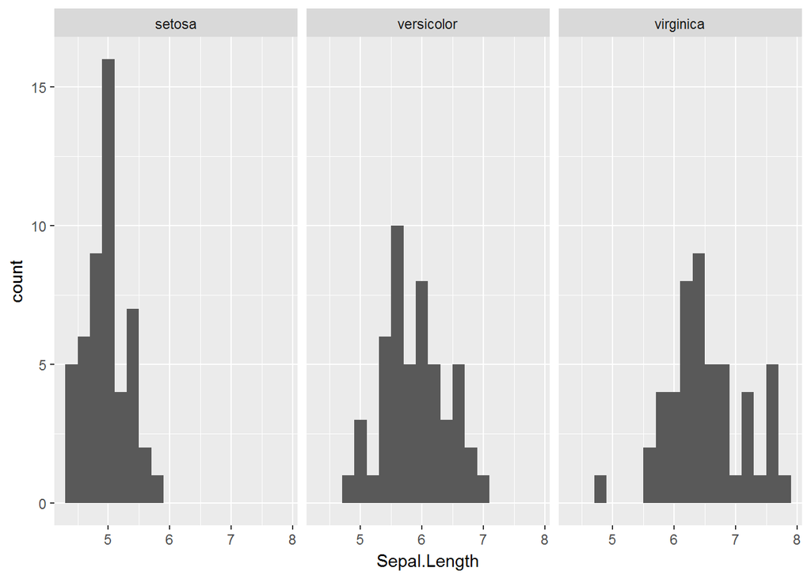

```r
ggplot(iris, aes(x = Sepal.Length)) +
  geom_histogram(binwidth = 0.2) +
  facet_wrap(~ Species)
```

加入`ncol`引數，可調整畫布規格。

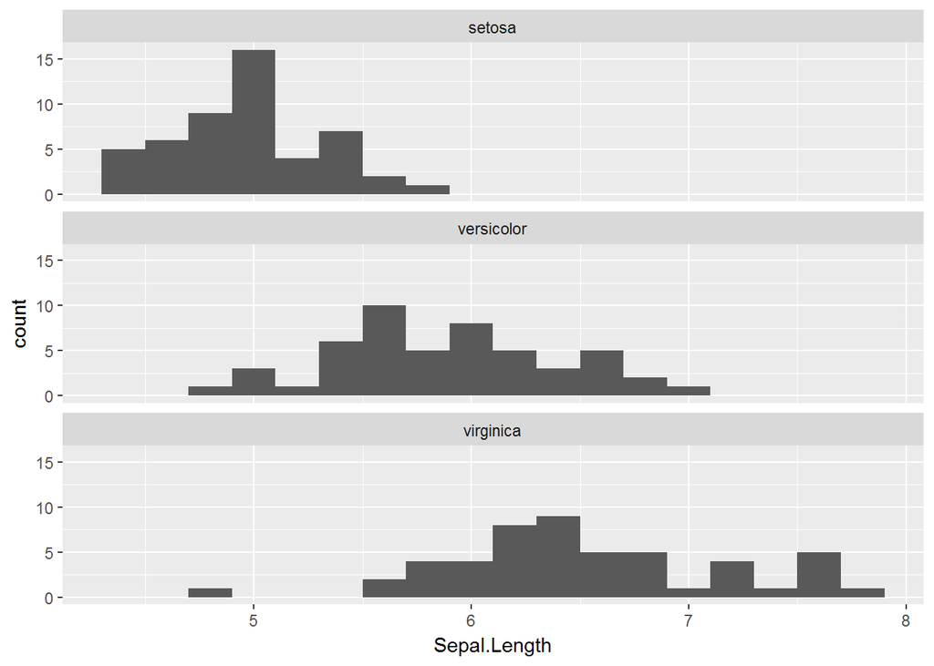

```r
ggplot(iris, aes(x = Sepal.Length)) +
  geom_histogram(binwidth = 0.2) +
  facet_wrap(~ Species, ncol = 1)
```

# **4. 盒鬚圖(Boxplot)**

玩具資料採用`iris`，分別觀察不同品種(Species)的萼片(Sepal)之長度(Length)之分布。

## **4.1. 畫盒鬚圖**

使用`ggplot() + geom_boxplot()`繪製盒鬚圖

# 預設要讓aes吃一個x值

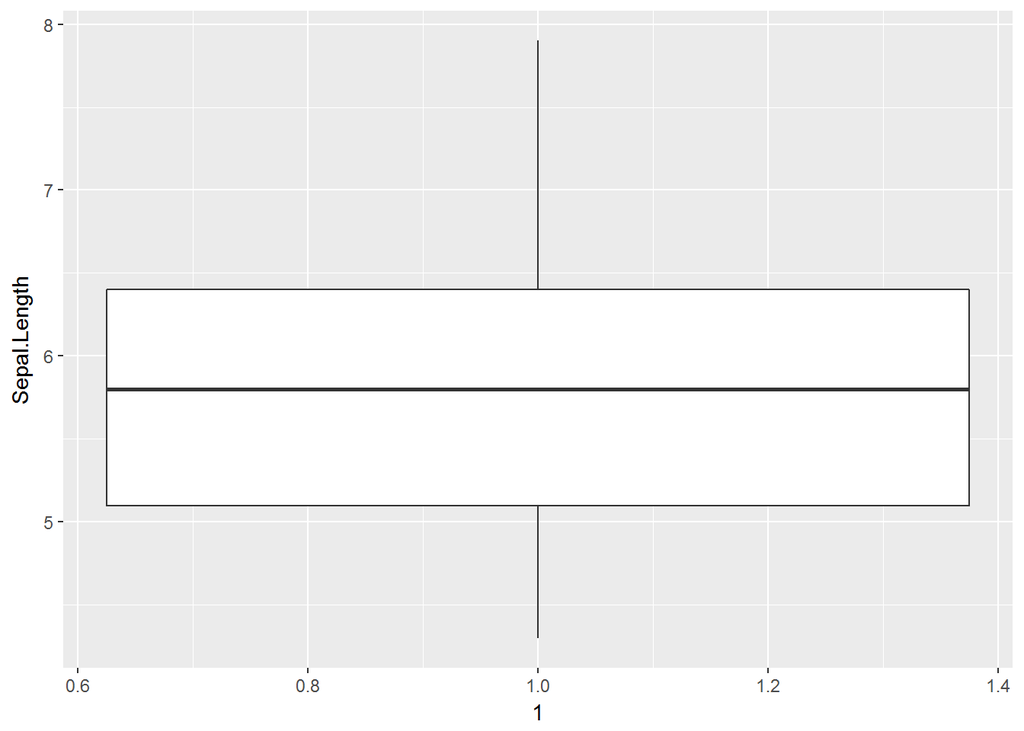

```r
ggplot(iris, aes(x = 1, y = Sepal.Length)) +
  geom_boxplot()
```

## **4.2. 其他功能**

### **4.2.1. 分類畫圖**

# aes() 指定 x = 納入類別變數的展開

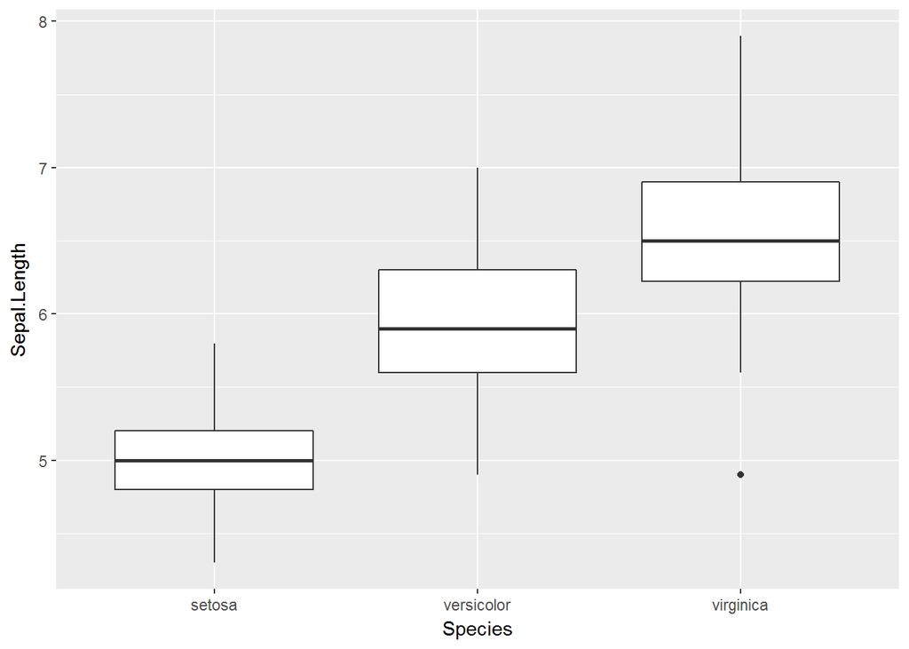

```r
ggplot(iris, aes(x = Species, y = Sepal.Length)) +
  geom_boxplot()
```

# **5. 長條圖(Bar chart)**

玩具資料採用`mtcars`，為不同齒輪(gear)之車輛數作計數，以及列出每種車型的馬力(hp)。

## **5.1. 畫長條圖**

使用`ggplot() + geom_bar()`繪製長條圖

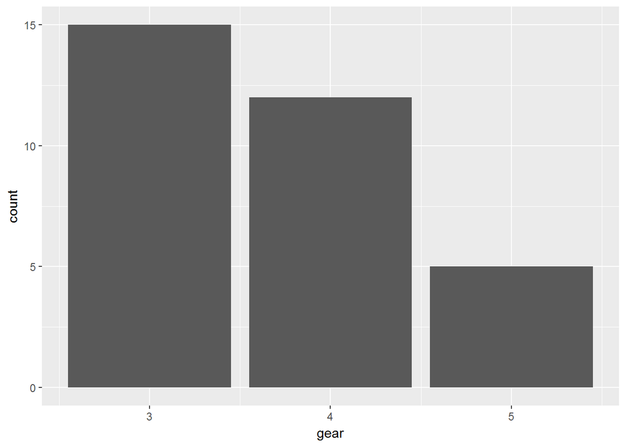

```r
ggplot(mtcars, aes(x = gear)) +
  geom_bar()
```

## **5.2. 其他功能**

### **5.2.1. 顯示數值

```
ggplot(mtcars, aes(x = row.names(mtcars), y = hp)) +
  geom_bar()
```

發現上述指令會出現error訊息，原因是預設y值為`"count"`，作**計數**的動作。然而在此想呈現馬力(hp)數值高低，因此得調整函數`geom_bar`中的引數`stat`。

# geom_bar(stat = “identity”)：呈現數值

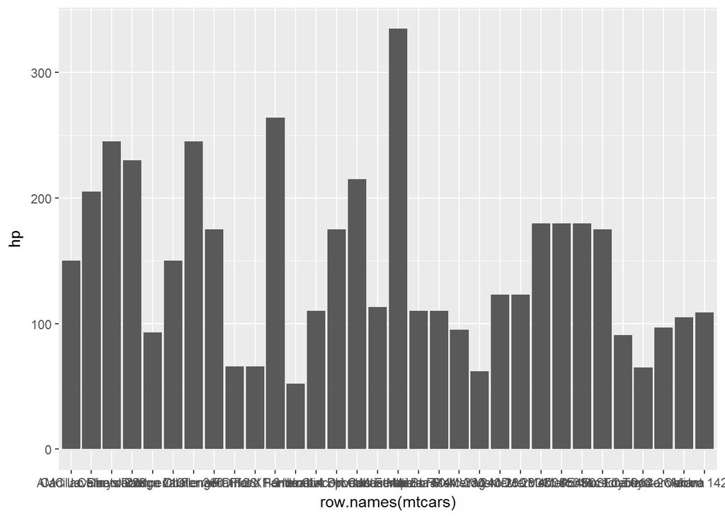

```r
ggplot(mtcars, aes(x = row.names(mtcars), y = hp)) +
  geom_bar(stat = "identity")
```

### **5.2.2. 座標翻轉**

# cood_flip()：座標翻轉

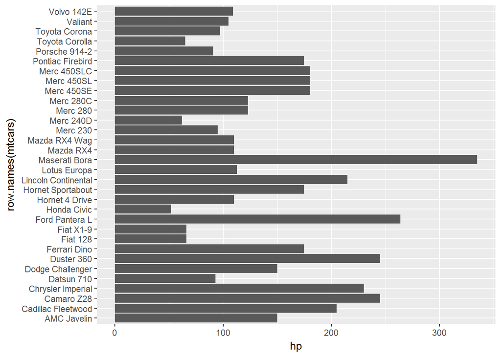

```r
ggplot(mtcars, aes(x = row.names(mtcars), y = hp)) +
  geom_bar(stat = "identity") + coord_flip()
```

### **5.2.3. 類別著色**

玩具資料採用`mpg`，觀察各車型(class)的數量，並區分車輪驅動方式(drv)。

# geom_bar(aes(fill = (drv)))：依照類別drv為長條圖著色

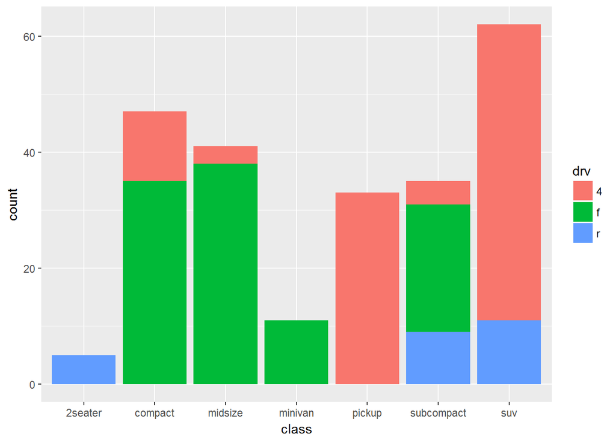

```r
ggplot(mpg, aes(x = class)) +
  geom_bar(aes(fill = drv))
```

可選擇依類別將長條分開

# 加入 position = “dodge” 參數

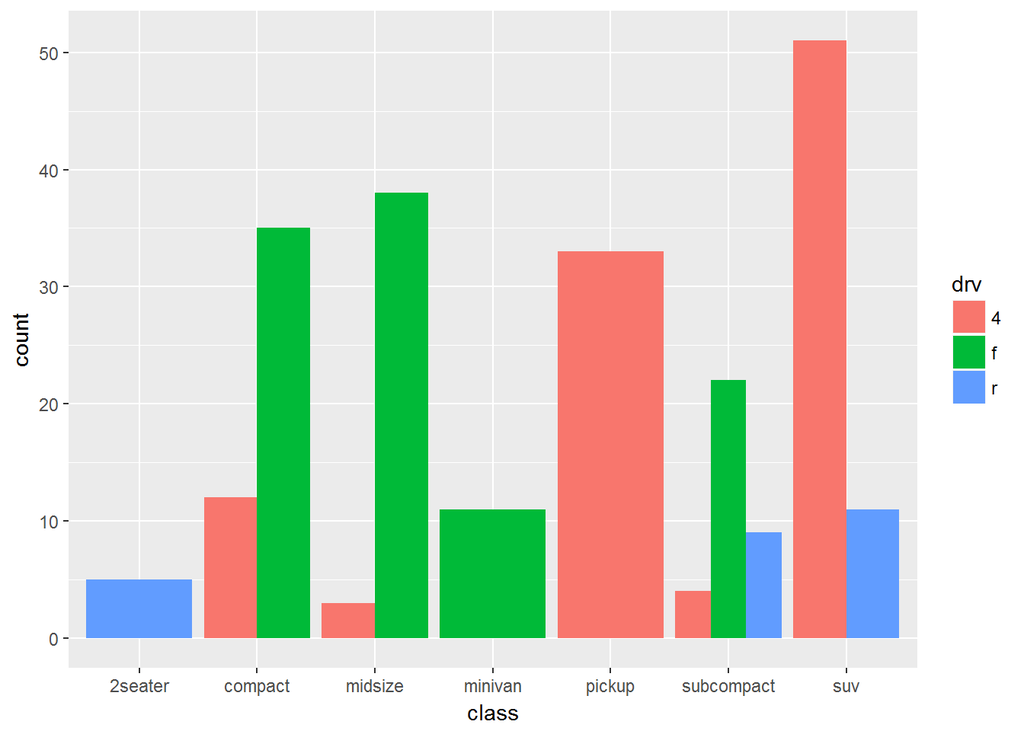

```r
ggplot(mpg, aes(x = class)) +
  geom_bar(aes(fill = drv), position = "dodge")
```

亦可觀察各車型(class)，各車輪驅動方式(drv)之百分比。

# 加入 position = “fill” 參數

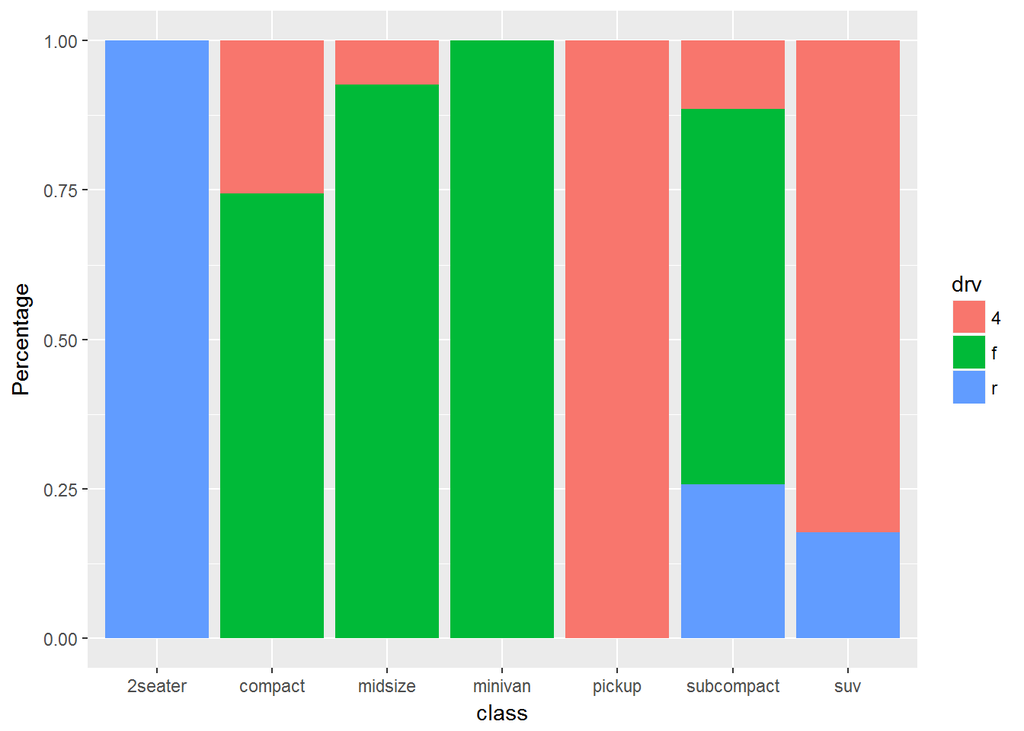

```r
ggplot(mpg, aes(x = class)) +
  geom_bar(aes(fill = drv), position = "fill") +
  ylab("Percentage")
```

# **6. 圖形互動(`ggplotly`)**

## **6.1. 安裝及載入套件`plotly`**

# 安裝套件

```
install.packages("plotly")
```

# 載入套件

```r
library(plotly)
```

## **6.2. 加入互動性**

# ggplotly()：新增互動功能

```r
static_gg <- ggplot(mpg, aes(x = class)) +
  geom_bar(aes(fill = drv))
ggplotly(static_gg)
```

[interactive chart not shown]